# MiTH

## Visualisation

1. Job Role v/s Extra Time

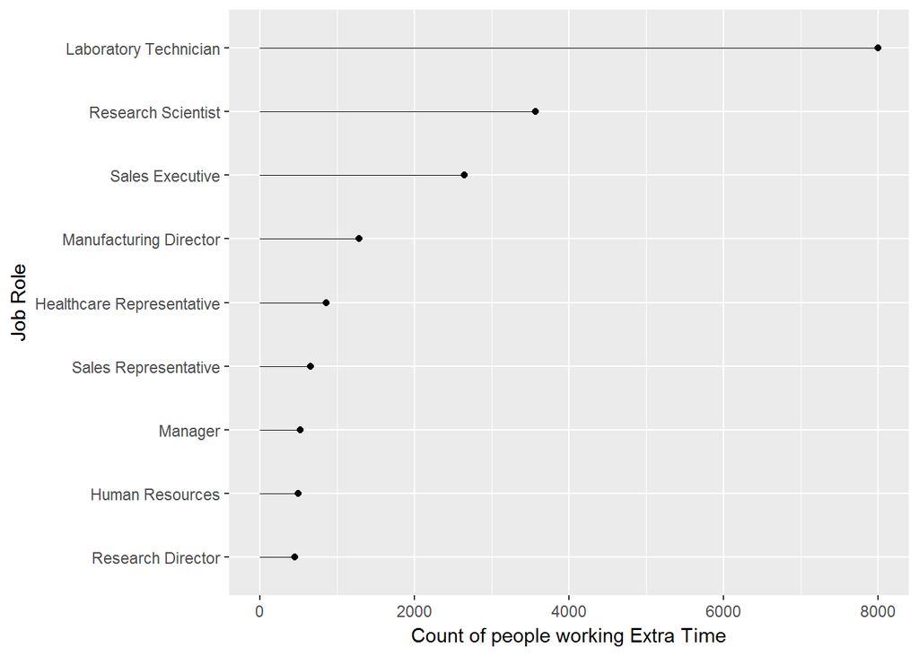

```r
train %>%
  count(JobRole,ExtraTime) %>%
  filter(ExtraTime == 'Yes') %>%
  ggplot(aes(n,reorder(JobRole,n))) +
  geom_point() +
  xlab('Count of people working Extra Time') + ylab('Job Role') +
  geom_segment(aes(x = 0, xend = n, y = JobRole, yend = JobRole), size = .15)
```

2. Job Level v/s Extra Time

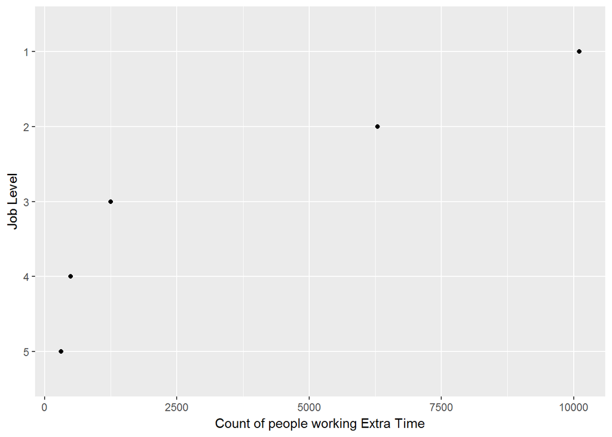

```r
train %>%
  count(Joblevel,ExtraTime) %>%
  filter(ExtraTime == 'Yes') %>%
  ggplot(aes(n,reorder(Joblevel,n))) +
  geom_point() +
  xlab('Count of people working Extra Time') + ylab('Job Level')
```

3. Gender v/s Extra Time

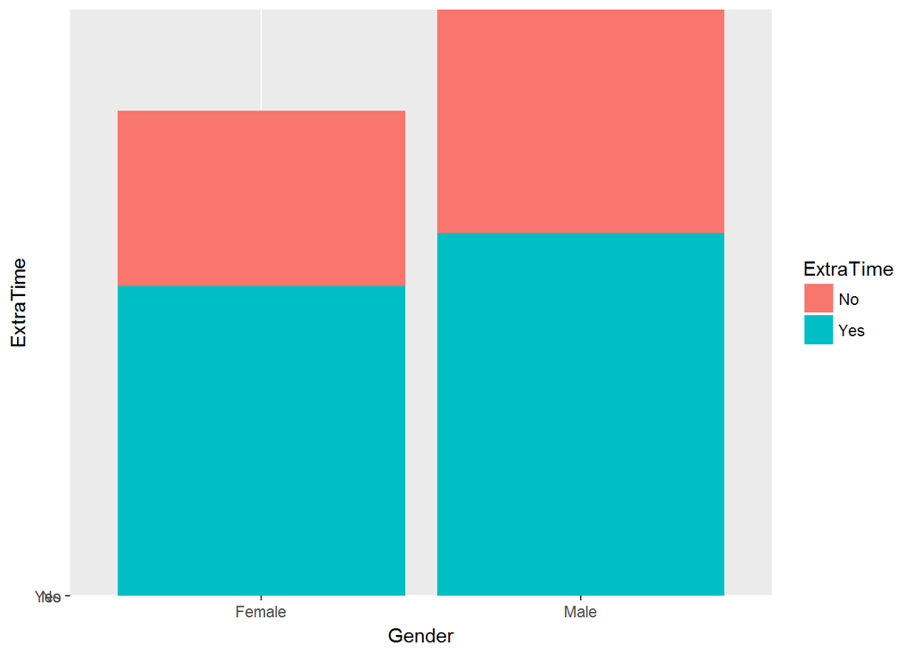

```r
 p <- ggplot(train, aes(Gender,ExtraTime))
 p + geom_bar(stat = "identity", aes(fill = ExtraTime))
```

4. Department v/s Extra Time

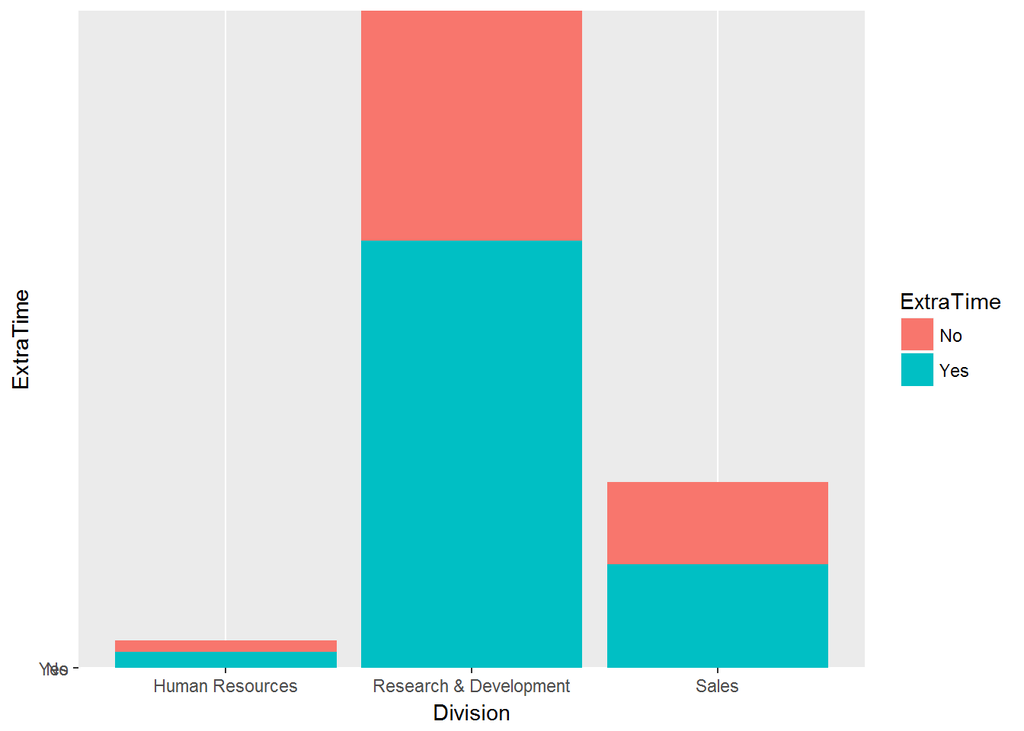

```r
 p <- ggplot(train, aes(Division,ExtraTime))
 p + geom_bar(stat = "identity", aes(fill = ExtraTime))
```

# 1) isTrain and Row ID is dropped initially

# Additionaly drop Employee ID

```r
train$EmployeeID <- NULL
test$EmployeeID <- NULL
```

## 2) Columns with a unique value and handling

Over18, EmployeeCount and StandardHours has only one value. They can be dropped

```r
length(unique(train$Over18))
```

```
## [1] 1
```

```r
length(unique(train$EmployeeCount))
```

```
## [1] 1
```

```r
length(unique(train$StandardHours))
```

```
## [1] 1
```

```r
# Columns Over18 and StandardHours has only one value, they can be dropped due to no variance

train$Over18 <- NULL
test$Over18 <- NULL
train$StandardHours <- NULL
test$StandardHours <- NULL
train$EmployeeCount <- NULL
test$EmployeeCount <- NULL
```

```r
summary(train)
```

```
##     Joblevel     DistancetoHome   FrequencyofTravel    Gender
##  Min.   :1.000   Min.   : 1.000   High    : 7138    Female:18111
##  1st Qu.:1.000   1st Qu.: 3.000   Less    :30254    Male  :22192
##  Median :2.000   Median : 7.000   NoTravel: 2911
##  Mean   :1.907   Mean   : 9.309
##  3rd Qu.:2.000   3rd Qu.:14.000
##  Max.   :5.000   Max.   :29.000
##
##  OfficeAmbienceRating  MonthlyRate    YearsSinceLastPromotion
##  Min.   :1.000        Min.   : 2094   Min.   : 0.000
##  1st Qu.:2.000        1st Qu.: 8744   1st Qu.: 0.000
##  Median :3.000        Median :13077   Median : 1.000
##  Mean   :2.896        Mean   :13692   Mean   : 1.781
##  3rd Qu.:4.000        3rd Qu.:19002   3rd Qu.: 2.000
##  Max.   :4.000        Max.   :26968   Max.   :15.000
##
##  SelfMotivationRating                   Division       Hourlyrate
##  Min.   :1.000        Human Resources       : 1303   Min.   : 30.0
##  1st Qu.:2.000        Research & Development:29959   1st Qu.: 51.0
##  Median :3.000        Sales                 : 9041   Median : 65.0
##  Mean   :2.684                                       Mean   : 66.2
##  3rd Qu.:3.000                                       3rd Qu.: 82.0
##  Max.   :4.000                                       Max.   :100.0
##
##                       JobRole      RelationshipSatisfaction
##  Laboratory Technician    :13283   Min.   :1.000
##  Research Scientist       : 7059   1st Qu.:2.000
##  Sales Executive          : 6598   Median :3.000
##  Manufacturing Director   : 3573   Mean   :2.585
##  Healthcare Representative: 2984   3rd Qu.:3.000
##  Manager                  : 2101   Max.   :4.000
##  (Other)                  : 4705
##    Education     No.ofWorkshopsAttended   datacollected        Age
##  Min.   :1.000   Min.   :0.000          3/20/2014:40303   Min.   :18.00
##  1st Qu.:2.000   1st Qu.:2.000                            1st Qu.:31.00
##  Median :3.000   Median :3.000                            Median :36.00
##  Mean   :2.877   Mean   :2.916                            Mean   :37.73
##  3rd Qu.:4.000   3rd Qu.:3.000                            3rd Qu.:44.00
##  Max.   :5.000   Max.   :6.000                            Max.   :60.00
##
```

[output cut: 25 more lines]

```
##  Min.   : 1074   Human Resources :  520   Min.   :3.000
##  1st Qu.: 2823   Life Sciences   :18365   1st Qu.:3.000
##  Median : 4287   Marketing       : 3172   Median :3.000
##  Mean   : 5860   Medical         :11943   Mean   :3.162
##  3rd Qu.: 6852   Other           : 3799   3rd Qu.:3.000
##  Max.   :19999   Technical Degree: 2504   Max.   :4.000
##
##   MaritalStatus
##  Divorced: 6251
##  Married :18651
##  Single  :15401
##
##
##
##
```

## Check if Division categories and JobRoles add up in the entire dataset

# Initial data is called again

```r
data <- read.csv("dataset.csv", header = T)
summary(data$Division)
```

```
##        Human Resources Research & Development                  Sales
##                   1626                  37383                  11332
```

```r
summary(data$JobRole)
```

```
## Healthcare Representative           Human Resources
##                      3722                      1435
##     Laboratory Technician                   Manager
##                     16558                      2631
##    Manufacturing Director         Research Director
##                      4459                      2463
##        Research Scientist           Sales Executive
##                      8822                      8277
##      Sales Representative
##                      1974
```

```r
rm(data)
```

Since, no column can be explained as the sum of multiple columns, need to keep both Division and JobRole

## 3) Handling Date columns

# Creation of two new columns

# workExp - Number of days between initial joining date and date of data collection

# currentExp - Number of days between joining date in this company and date of data collection

```r
train$workExp <- as.Date(as.character(train$datacollected), format="%m/%d/%Y")-
                  as.Date(as.character(train$FirstJobDate), format="%m/%d/%Y")
train$currentExp <- as.Date(as.character(train$datacollected), format="%m/%d/%Y")-
                  as.Date(as.character(train$DateOfjoiningintheCurrentCompany), format="%m/%d/%Y")


test$workExp <- as.Date(as.character(test$datacollected), format="%m/%d/%Y")-
                  as.Date(as.character(test$FirstJobDate), format="%m/%d/%Y")
test$currentExp <- as.Date(as.character(test$datacollected), format="%m/%d/%Y")-
                  as.Date(as.character(test$DateOfjoiningintheCurrentCompany), format="%m/%d/%Y")
```

# Converting to numeric type for arithemtic operations

```r
class(train$workExp)
```

```
## [1] "difftime"
```

```r
# Type is difftime. Converting to numeric

train$workExp <- as.numeric(train$workExp)
train$currentExp <- as.numeric(train$currentExp)

test$workExp <- as.numeric(test$workExp)
test$currentExp <- as.numeric(test$currentExp)

class(train$workExp)
```

```
## [1] "numeric"
```

# Check for negative value - some values are negative in train and test because data is collected after the reference dataCollected column

```r
min(train$workExp)
```

```
## [1] -128
```

```r
min(train$currentExp)
```

```
## [1] -132
```

```r
min(test$workExp)
```

```
## [1] -129
```

```r
min(test$currentExp)
```

```
## [1] -132
```

# Converting negative days to positive along with converting days to year rounded off to 1 decimal

```r
train$workExp <- abs(round(train$workExp/365, digits = 1))
train$currentExp <- abs(round(train$currentExp/365, digits = 1))

test$workExp <- abs(round(test$workExp/365, digits = 1))
test$currentExp <- abs(round(test$currentExp/365, digits = 1))
```

# Dropping date columns - datacollected, FirstJobDate and DateOfjoiningintheCurrentCompany

```r
train$datacollected <- NULL
train$FirstJobDate <- NULL
train$DateOfjoiningintheCurrentCompany <- NULL

test$datacollected <- NULL
test$FirstJobDate <- NULL
test$DateOfjoiningintheCurrentCompany <- NULL
```

## 4) Conversion of factors for categorical variables

```r
train$Joblevel <- as.factor(as.character(train$Joblevel))
test$Joblevel <- as.factor(as.character(test$Joblevel))
train$Education <- as.factor(as.character(train$Education))
test$Education <- as.factor(as.character(test$Education))
```

# Ratings are not converted to factors since their average makes sense

```r
summary(train)
```

```
##  Joblevel  DistancetoHome   FrequencyofTravel    Gender
##  1:17412   Min.   : 1.000   High    : 7138    Female:18111
##  2:14394   1st Qu.: 3.000   Less    :30254    Male  :22192
##  3: 4841   Median : 7.000   NoTravel: 2911
##  4: 2155   Mean   : 9.309
##  5: 1501   3rd Qu.:14.000
##            Max.   :29.000
##
##  OfficeAmbienceRating  MonthlyRate    YearsSinceLastPromotion
##  Min.   :1.000        Min.   : 2094   Min.   : 0.000
##  1st Qu.:2.000        1st Qu.: 8744   1st Qu.: 0.000
##  Median :3.000        Median :13077   Median : 1.000
##  Mean   :2.896        Mean   :13692   Mean   : 1.781
##  3rd Qu.:4.000        3rd Qu.:19002   3rd Qu.: 2.000
##  Max.   :4.000        Max.   :26968   Max.   :15.000
##
##  SelfMotivationRating                   Division       Hourlyrate
##  Min.   :1.000        Human Resources       : 1303   Min.   : 30.0
##  1st Qu.:2.000        Research & Development:29959   1st Qu.: 51.0
##  Median :3.000        Sales                 : 9041   Median : 65.0
##  Mean   :2.684                                       Mean   : 66.2
##  3rd Qu.:3.000                                       3rd Qu.: 82.0
##  Max.   :4.000                                       Max.   :100.0
##
##                       JobRole      RelationshipSatisfaction Education
##  Laboratory Technician    :13283   Min.   :1.000            1: 3084
##  Research Scientist       : 7059   1st Qu.:2.000            2:10039
##  Sales Executive          : 6598   Median :3.000            3:16978
##  Manufacturing Director   : 3573   Mean   :2.585            4: 9145
##  Healthcare Representative: 2984   3rd Qu.:3.000            5: 1057
##  Manager                  : 2101   Max.   :4.000
##  (Other)                  : 4705
##  No.ofWorkshopsAttended      Age        YearsInCurrentRole
##  Min.   :0.000          Min.   :18.00   Min.   : 0.000
##  1st Qu.:2.000          1st Qu.:31.00   1st Qu.: 2.000
##  Median :3.000          Median :36.00   Median : 3.000
##  Mean   :2.916          Mean   :37.73   Mean   : 3.772
##  3rd Qu.:3.000          3rd Qu.:44.00   3rd Qu.: 6.000
##  Max.   :6.000          Max.   :60.00   Max.   :18.000
##
```

[output cut: 17 more lines]

```
##  Min.   : 1074   Human Resources :  520   Min.   :3.000
##  1st Qu.: 2823   Life Sciences   :18365   1st Qu.:3.000
##  Median : 4287   Marketing       : 3172   Median :3.000
##  Mean   : 5860   Medical         :11943   Mean   :3.162
##  3rd Qu.: 6852   Other           : 3799   3rd Qu.:3.000
##  Max.   :19999   Technical Degree: 2504   Max.   :4.000
##
##   MaritalStatus      workExp        currentExp
##  Divorced: 6251   Min.   : 0.10   Min.   : 0.100
##  Married :18651   1st Qu.: 6.80   1st Qu.: 2.700
##  Single  :15401   Median : 9.70   Median : 4.800
##                   Mean   :10.92   Mean   : 6.083
##                   3rd Qu.:12.90   3rd Qu.: 7.900
##                   Max.   :39.90   Max.   :39.900
##
```

```r
str(train)
```

```
## 'data.frame':    40303 obs. of  29 variables:
##  $ Joblevel                : Factor w/ 5 levels "1","2","3","4",..: 1 2 1 1 1 1 2 3 2 3 ...
##  $ DistancetoHome          : int  3 15 24 5 2 5 5 1 1 11 ...
##  $ FrequencyofTravel       : Factor w/ 3 levels "High","Less",..: 2 2 2 2 2 2 1 2 2 3 ...
##  $ Gender                  : Factor w/ 2 levels "Female","Male": 1 1 2 2 2 1 2 2 1 2 ...
##  $ OfficeAmbienceRating    : int  3 4 3 1 4 2 1 1 2 3 ...
##  $ MonthlyRate             : int  9964 12682 12947 15053 4306 13072 20445 19294 4009 8302 ...
##  $ YearsSinceLastPromotion : int  0 0 0 0 1 0 0 0 1 2 ...
##  $ SelfMotivationRating    : int  4 2 2 4 3 2 3 2 3 2 ...
##  $ Division                : Factor w/ 3 levels "Human Resources",..: 2 2 2 2 2 2 3 2 3 2 ...
##  $ Hourlyrate              : int  81 49 50 80 45 82 98 98 75 79 ...
##  $ JobRole                 : Factor w/ 9 levels "Healthcare Representative",..: 3 3 3 7 7 7 8 3 8 1 ...
##  $ RelationshipSatisfaction: int  1 4 2 4 3 4 3 4 3 3 ...
##  $ Education               : Factor w/ 5 levels "1","2","3","4",..: 3 2 3 2 3 4 4 2 5 2 ...
##  $ No.ofWorkshopsAttended  : int  3 3 4 5 3 3 4 2 2 3 ...
##  $ Age                     : int  59 29 28 32 38 36 46 48 44 35 ...
##  $ YearsInCurrentRole      : int  0 5 2 2 2 1 6 0 3 0 ...
##  $ NumberofCompaniesChanged: int  4 0 5 0 5 9 4 9 5 2 ...
##  $ WorkLifeBalance         : int  2 3 3 2 3 4 3 3 2 3 ...
##  $ Emolumnet_in_Pecentage  : int  20 12 14 12 11 14 21 13 21 13 ...
##  $ DialyRate               : int  1324 153 103 334 371 852 1211 626 1488 1097 ...
##  $ ExtraTime               : Factor w/ 2 levels "No","Yes": 1 1 1 2 1 2 2 2 1 2 ...
##  $ Happynesslevelinjob     : int  1 3 3 2 4 1 4 3 1 1 ...
##  $ ESOps                   : int  3 0 0 2 0 1 0 0 1 1 ...
##  $ MonthlyIncome           : int  2670 4193 2028 3298 3944 3419 5772 5381 5454 9884 ...
##  $ Specialization          : Factor w/ 6 levels "Human Resources",..: 4 2 2 2 2 2 3 2 3 4 ...
##  $ PerformanceRating       : int  4 3 3 3 3 3 4 3 4 3 ...
##  $ MaritalStatus           : Factor w/ 3 levels "Divorced","Married",..: 2 3 3 1 3 2 3 3 1 2 ...
##  $ workExp                 : num  11.7 9.8 5.9 6.7 5.7 5.6 13.7 22.8 8.8 9.7 ...
##  $ currentExp              : num  0.8 8.9 3.9 5.6 2.7 0.7 8.7 0.6 3.9 3.8 ...
```

```r
summary(test)
```

```
##  Joblevel DistancetoHome   FrequencyofTravel    Gender
##  1:4363   Min.   : 1.000   High    :1726     Female:4499
##  2:3533   1st Qu.: 3.000   Less    :7562     Male  :5539
##  3:1234   Median : 7.000   NoTravel: 750
##  4: 572   Mean   : 9.327
##  5: 336   3rd Qu.:14.000
##           Max.   :29.000
##
##  OfficeAmbienceRating  MonthlyRate    YearsSinceLastPromotion
##  Min.   :1.000        Min.   : 2094   Min.   : 0.000
##  1st Qu.:2.000        1st Qu.: 8424   1st Qu.: 0.000
##  Median :3.000        Median :13004   Median : 1.000
##  Mean   :2.878        Mean   :13599   Mean   : 1.749
##  3rd Qu.:4.000        3rd Qu.:18899   3rd Qu.: 2.000
##  Max.   :4.000        Max.   :26968   Max.   :15.000
##
##  SelfMotivationRating                   Division      Hourlyrate
##  Min.   :1.000        Human Resources       : 323   Min.   : 30.00
##  1st Qu.:2.000        Research & Development:7424   1st Qu.: 52.00
##  Median :3.000        Sales                 :2291   Median : 66.00
##  Mean   :2.687                                      Mean   : 66.53
##  3rd Qu.:3.000                                      3rd Qu.: 82.00
##  Max.   :4.000                                      Max.   :100.00
##
##                       JobRole     RelationshipSatisfaction Education
##  Laboratory Technician    :3275   Min.   :1.000            1: 756
##  Research Scientist       :1763   1st Qu.:2.000            2:2467
##  Sales Executive          :1679   Median :3.000            3:4272
##  Manufacturing Director   : 886   Mean   :2.579            4:2301
##  Healthcare Representative: 738   3rd Qu.:3.000            5: 242
##  Manager                  : 530   Max.   :4.000
##  (Other)                  :1167
##  No.ofWorkshopsAttended      Age        YearsInCurrentRole
##  Min.   :0.000          Min.   :18.00   Min.   : 0.000
##  1st Qu.:2.000          1st Qu.:31.00   1st Qu.: 2.000
##  Median :3.000          Median :36.00   Median : 3.000
##  Mean   :2.908          Mean   :37.71   Mean   : 3.759
##  3rd Qu.:3.000          3rd Qu.:44.00   3rd Qu.: 6.000
##  Max.   :6.000          Max.   :60.00   Max.   :18.000
##
```

[output cut: 17 more lines]

```
##  Human Resources : 123   Min.   :3.000     Divorced:1577   Min.   : 0.10
##  Life Sciences   :4466   1st Qu.:3.000     Married :4616   1st Qu.: 6.70
##  Marketing       : 791   Median :3.000     Single  :3845   Median : 9.70
##  Medical         :2989   Mean   :3.162                     Mean   :10.96
##  Other           :1033   3rd Qu.:3.000                     3rd Qu.:13.70
##  Technical Degree: 636   Max.   :4.000                     Max.   :39.80
##
##    currentExp
##  Min.   : 0.100
##  1st Qu.: 2.600
##  Median : 4.800
##  Mean   : 6.046
##  3rd Qu.: 7.900
##  Max.   :39.800
##
```

```r
str(test)
```

```
## 'data.frame':    10038 obs. of  28 variables:
##  $ Joblevel                : Factor w/ 5 levels "1","2","3","4",..: 2 1 2 1 1 5 4 3 2 2 ...
##  $ DistancetoHome          : int  1 2 10 1 3 7 8 6 6 21 ...
##  $ FrequencyofTravel       : Factor w/ 3 levels "High","Less",..: 2 2 2 2 2 2 2 2 3 2 ...
##  $ Gender                  : Factor w/ 2 levels "Female","Male": 1 2 2 2 2 1 1 2 1 2 ...
##  $ OfficeAmbienceRating    : int  2 4 4 2 1 2 4 4 2 3 ...
##  $ MonthlyRate             : int  19479 2396 19121 3020 3810 16701 19730 15067 15717 8423 ...
##  $ YearsSinceLastPromotion : int  0 0 1 2 0 13 0 0 1 1 ...
##  $ SelfMotivationRating    : int  3 2 3 3 2 2 3 3 1 3 ...
##  $ Division                : Factor w/ 3 levels "Human Resources",..: 3 2 2 2 3 2 2 2 2 3 ...
##  $ Hourlyrate              : int  94 92 41 61 86 43 33 52 79 71 ...
##  $ JobRole                 : Factor w/ 9 levels "Healthcare Representative",..: 8 3 1 7 9 6 4 6 7 8 ...
##  $ RelationshipSatisfaction: int  1 2 4 1 3 4 3 2 4 4 ...
##  $ Education               : Factor w/ 5 levels "1","2","3","4",..: 2 2 4 3 2 2 3 4 3 4 ...
##  $ No.ofWorkshopsAttended  : int  0 3 5 2 2 2 2 3 3 2 ...
##  $ Age                     : int  41 37 44 24 50 50 55 45 38 51 ...
##  $ YearsInCurrentRole      : int  4 0 2 0 2 3 0 0 11 7 ...
##  $ NumberofCompaniesChanged: int  8 6 2 2 1 5 2 4 7 0 ...
##  $ WorkLifeBalance         : int  1 3 4 2 3 2 3 4 3 1 ...
##  $ Emolumnet_in_Pecentage  : int  11 15 13 16 14 12 14 14 12 22 ...
##  $ DialyRate               : int  1102 1373 1459 813 869 989 836 193 573 632 ...
##  $ Happynesslevelinjob     : int  4 3 4 4 3 3 3 1 4 4 ...
##  $ ESOps                   : int  0 0 0 1 0 1 3 0 3 0 ...
##  $ MonthlyIncome           : int  5993 2090 6465 2293 2683 18740 14756 13245 5329 5441 ...
##  $ Specialization          : Factor w/ 6 levels "Human Resources",..: 2 5 5 4 3 4 4 5 4 3 ...
##  $ PerformanceRating       : int  3 3 3 3 3 3 3 3 3 4 ...
##  $ MaritalStatus           : Factor w/ 3 levels "Divorced","Married",..: 3 3 2 2 2 1 1 2 1 3 ...
##  $ workExp                 : num  7.9 6.7 8.7 5.9 2.8 28.9 20.9 16.7 16.7 10.9 ...
##  $ currentExp              : num  5.7 0.3 3.6 1.9 2.6 26.7 4.8 0.2 12.8 9.6 ...
```

### Train Data split to train and validation

```r
set.seed(786)

train_rows <- createDataPartition(train$ExtraTime, p = 0.7,list = F)

train_data <- train[train_rows, ]
validation_data <- train[-train_rows, ]
rm(train_rows)
```

# Check proprotion of target variable in train and validation dataset

```r
prop.table(table(train$ExtraTime))
```

```
##
##        No       Yes
## 0.5421929 0.4578071
```

```r
prop.table(table(train_data$ExtraTime))
```

```
##
##        No       Yes
## 0.5421969 0.4578031
```

```r
prop.table(table(validation_data$ExtraTime))
```

```
##
##        No       Yes
## 0.5421836 0.4578164
```

## Model 1

## Random Forest

```r
library(DMwR)
library(randomForest)
library(caret)

set.seed(123)

# RandomForest classification model
rf_model = randomForest(ExtraTime ~ ., data=train_data, keep.forest=TRUE, ntree=100)

print(rf_model) # Summary of model
```

```
##
## Call:
##  randomForest(formula = ExtraTime ~ ., data = train_data, keep.forest = TRUE,      ntree = 100)
##                Type of random forest: classification
##                      Number of trees: 100
## No. of variables tried at each split: 5
##
##         OOB estimate of  error rate: 25.03%
## Confusion matrix:
##        No  Yes class.error
## No  11886 3411   0.2229849
## Yes  3651 9265   0.2826727
```

```r
rf_model$importance
```

```
##                          MeanDecreaseGini
## Joblevel                        271.77151
## DistancetoHome                  355.77732
## FrequencyofTravel                92.65765
## Gender                           80.35607
## OfficeAmbienceRating            219.06284
## MonthlyRate                     574.33887
## YearsSinceLastPromotion         233.01720
## SelfMotivationRating             96.23648
## Division                         69.50349
## Hourlyrate                      442.82256
## JobRole                         547.07867
## RelationshipSatisfaction        125.87385
## Education                       157.61942
## No.ofWorkshopsAttended          190.14896
## Age                             413.93194
## YearsInCurrentRole              360.31912
## NumberofCompaniesChanged        290.01180
## WorkLifeBalance                  81.78032
## Emolumnet_in_Pecentage          274.08177
## DialyRate                       542.41743
## Happynesslevelinjob             170.55738
## ESOps                           119.01476
## MonthlyIncome                   892.84544
## Specialization                  228.53993
## PerformanceRating                29.20237
## MaritalStatus                   141.73477
## workExp                        1735.77852
## currentExp                      807.07309
```

```r
round(importance(rf_model), 2) # Model importance of attributes rounded off to 2 decimals
```

```
##                          MeanDecreaseGini
## Joblevel                           271.77
## DistancetoHome                     355.78
## FrequencyofTravel                   92.66
## Gender                              80.36
## OfficeAmbienceRating               219.06
## MonthlyRate                        574.34
## YearsSinceLastPromotion            233.02
## SelfMotivationRating                96.24
## Division                            69.50
## Hourlyrate                         442.82
## JobRole                            547.08
## RelationshipSatisfaction           125.87
## Education                          157.62
## No.ofWorkshopsAttended             190.15
## Age                                413.93
## YearsInCurrentRole                 360.32
## NumberofCompaniesChanged           290.01
## WorkLifeBalance                     81.78
## Emolumnet_in_Pecentage             274.08
## DialyRate                          542.42
## Happynesslevelinjob                170.56
## ESOps                              119.01
## MonthlyIncome                      892.85
## Specialization                     228.54
## PerformanceRating                   29.20
## MaritalStatus                      141.73
## workExp                           1735.78
## currentExp                         807.07
```

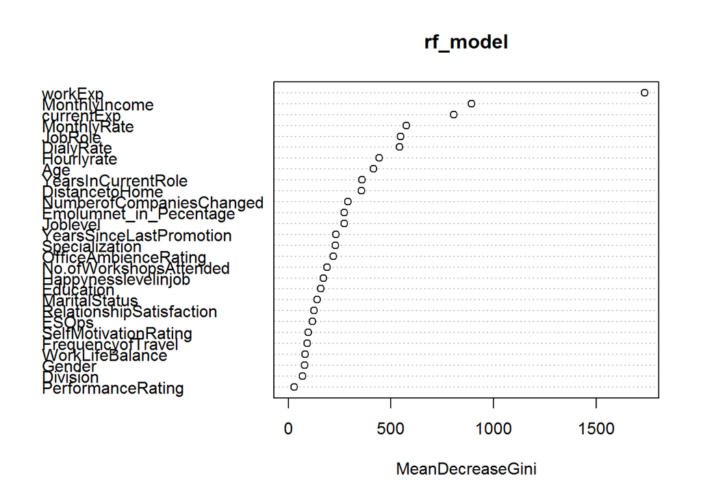

```r
# Store the impotant attributes in the RF model in decreasing order
rf_Imp_Attr = data.frame(rf_model$importance)
rf_Imp_Attr = data.frame(row.names(rf_Imp_Attr),rf_Imp_Attr[,1])
colnames(rf_Imp_Attr) = c('Attributes', 'Importance')
rf_Imp_Attr = rf_Imp_Attr[order(rf_Imp_Attr$Importance, decreasing = TRUE),]

varImpPlot(rf_model) # Plotting the important feautures
```

```r
# Prediction on train data
pred_Train = predict(rf_model, train_data[,setdiff(names(train_data), "ExtraTime")],
                     type="response", norm.votes=TRUE)

# Build confusion matrix and find accuracy of train data prediction
cm_Train = table("actual"= train_data$ExtraTime, "predicted" = pred_Train)
accu_Train= sum(diag(cm_Train))/sum(cm_Train)
rm(pred_Train, cm_Train)

# Predicton on test Data
pred_Test = predict(rf_model, validation_data[,setdiff(names(validation_data),"ExtraTime")],
                    type="response", norm.votes=TRUE)

# Build confusion matrix and find accuracy
cm_Test = table("actual"=validation_data$ExtraTime, "predicted"=pred_Test);
accu_Test= sum(diag(cm_Test))/sum(cm_Test)
rm(pred_Test, cm_Test)

accu_Train
```

```
## [1] 0.8768653
```

```r
accu_Test
```

```
## [1] 0.7497932
```

# Accuracy on validation data = 74.97%

## Model 2

## Random Forest with the top 14 attributes

```r
# Build randorm forest using top 55%  attributes
top_Imp_Attr = as.character(rf_Imp_Attr$Attributes[1:14])

set.seed(123)

# Build the classification model using randomForest
model_Imp = randomForest(ExtraTime~.,data=train_data[,c(top_Imp_Attr,"ExtraTime")],
                         keep.forest=TRUE,ntree=100)

print(model_Imp) # Model and Importance of model
```

```
##
## Call:
##  randomForest(formula = ExtraTime ~ ., data = train_data[, c(top_Imp_Attr,      "ExtraTime")], keep.forest = TRUE, ntree = 100)
##                Type of random forest: classification
##                      Number of trees: 100
## No. of variables tried at each split: 3
##
##         OOB estimate of  error rate: 25.58%
## Confusion matrix:
##        No  Yes class.error
## No  11872 3425   0.2239001
## Yes  3791 9125   0.2935119
```

```r
model_Imp$importance
```

```
##                          MeanDecreaseGini
## workExp                         1956.2125
## MonthlyIncome                   1123.2756
## currentExp                       995.5933
## MonthlyRate                      795.0411
## JobRole                          589.0195
## DialyRate                        748.7722
## Hourlyrate                       595.0121
## Age                              554.7745
## YearsInCurrentRole               503.7101
## DistancetoHome                   514.4549
## NumberofCompaniesChanged         380.7376
## Emolumnet_in_Pecentage           388.8358
## Joblevel                         283.7126
## YearsSinceLastPromotion          294.1996
```

```r
# Predict on Train data
pred_Train = predict(model_Imp, train_data[,top_Imp_Attr],type="response", norm.votes=TRUE)

# Confusion matric and accuracy
cm_Train = table("actual" = train_data$ExtraTime, "predicted" = pred_Train);
accu_Train_Imp = sum(diag(cm_Train))/sum(cm_Train)
rm(pred_Train, cm_Train)

# Predicton Test Data
pred_Test = predict(model_Imp, validation_data[,top_Imp_Attr],type="response", norm.votes=TRUE)

# Build confusion matrix and find accuracy
cm_Test = table("actual" = validation_data$ExtraTime, "predicted" = pred_Test);
accu_Test_Imp = sum(diag(cm_Test))/sum(cm_Test)
rm(pred_Test, cm_Test)

accu_Train
```

```
## [1] 0.8768653
```

```r
accu_Test
```

```
## [1] 0.7497932
```

```r
accu_Train_Imp
```

```
## [1] 0.878992
```

```r
accu_Test_Imp
```

```
## [1] 0.7498759
```

# Accuracy on validation data = 74.98 %

# Select mtry value with minimum out of bag(OOB) error

```
## mtry = 5  OOB error = 25.4%
## Searching left ...
## mtry = 4     OOB error = 25.01%
## 0.01548981 0.01
## mtry = 3     OOB error = 24.97%
## 0.001275691 0.01
## Searching right ...
## mtry = 7     OOB error = 25.52%
## -0.02041106 0.01
```

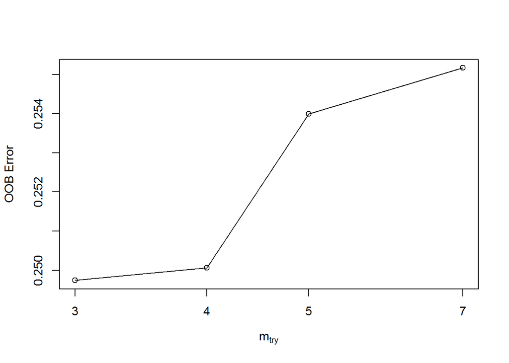

```r
mtry <- tuneRF(train_data[-21],train_data$ExtraTime, ntreeTry=100,
               stepFactor=1.5,improve=0.01, trace=TRUE, plot=TRUE) #train_data[-21] - Drop ExtraTime
```

```r
best.m <- mtry[mtry[, 2] == min(mtry[, 2]), 1]
print(mtry)
```

```
##       mtry  OOBError
## 3.OOB    3 0.2497430
## 4.OOB    4 0.2500620
## 5.OOB    5 0.2539964
## 7.OOB    7 0.2551661
```

```r
print(best.m)
```

```
## [1] 3
```

Best M is obtained as 3 with 24.97% OOB

## Model 3

## Random Forest with the best mtry = 3

```r
#Build Model with best mtry again -
set.seed(123)
rf <- randomForest(ExtraTime~.,data=train_data, mtry=best.m, importance=TRUE,ntree=100)
print(rf)
```

```
##
## Call:
##  randomForest(formula = ExtraTime ~ ., data = train_data, mtry = best.m,      importance = TRUE, ntree = 100)
##                Type of random forest: classification
##                      Number of trees: 100
## No. of variables tried at each split: 3
##
##         OOB estimate of  error rate: 24.85%
## Confusion matrix:
##        No  Yes class.error
## No  11781 3516    0.229849
## Yes  3496 9420    0.270672
```

```r
#Evaluate variable importance
importance(rf)
```

```
##                                 No         Yes MeanDecreaseAccuracy
## Joblevel                 14.497131   2.7854698            14.585368
## DistancetoHome           27.213751   4.6864918            31.943724
## FrequencyofTravel        16.301290  -3.0975013            17.159685
## Gender                   13.795725  -6.5455594            13.515484
## OfficeAmbienceRating     16.720673   4.9918958            18.436944
## MonthlyRate              20.203778   6.3290459            22.928226
## YearsSinceLastPromotion  15.382282   3.4787461            15.913557
## SelfMotivationRating     15.073096   2.2663211            13.940437
## Division                  7.897787  -3.0828500             8.423526
## Hourlyrate               23.473547   6.2359591            27.646279
## JobRole                  24.236016 -12.8316057            24.704157
## RelationshipSatisfaction 17.580117   3.9937128            18.093457
## Education                16.040314   0.3855048            15.961833
## No.ofWorkshopsAttended   12.204855  -0.3982920            13.359371
## Age                      14.997650   3.0629825            17.238500
## YearsInCurrentRole       21.510512   4.6002415            20.932718
## NumberofCompaniesChanged 21.914012   2.6268357            21.855499
## WorkLifeBalance          16.199076   3.3696768            18.126298
## Emolumnet_in_Pecentage   21.756110   6.4011966            23.650161
## DialyRate                26.598879   5.0381159            27.016534
## Happynesslevelinjob      13.297441   3.2786582            14.430756
## ESOps                    10.856117  -1.8323408            10.586929
## MonthlyIncome            24.436053   0.6545139            26.402990
## Specialization           20.955533  -4.6703590            22.043980
## PerformanceRating        13.434756  -1.6919493            10.687358
## MaritalStatus            13.589330  -8.6094674            13.984266
## workExp                  24.515610  18.3895721            29.067087
## currentExp               20.998751   9.8618343            21.846353
##                          MeanDecreaseGini
## Joblevel                        251.29432
## DistancetoHome                  356.41892
## FrequencyofTravel               103.13916
## Gender                           84.09150
## OfficeAmbienceRating            217.00024
## MonthlyRate                     525.42290
## YearsSinceLastPromotion         242.74316
## SelfMotivationRating            119.02750
## Division                         76.60465
## Hourlyrate                      426.24914
## JobRole                         487.36412
## RelationshipSatisfaction        149.21514
## Education                       173.43135
## No.ofWorkshopsAttended          195.13615
## Age                             425.69481
## YearsInCurrentRole              375.42502
## NumberofCompaniesChanged        300.09644
## WorkLifeBalance                  94.46588
## Emolumnet_in_Pecentage          291.36115
## DialyRate                       484.23687
## Happynesslevelinjob             182.57935
## ESOps                           135.57719
## MonthlyIncome                   785.34276
## Specialization                  230.41712
## PerformanceRating                38.72147
## MaritalStatus                   154.52228
## workExp                        1322.79163
## currentExp                      721.24920
```

```r
# Important attributes
rf$importance
```

```
##                                   No           Yes MeanDecreaseAccuracy
## Joblevel                 0.052255087  0.0047441753          0.030498383
## DistancetoHome           0.038484821  0.0044057062          0.022881045
## FrequencyofTravel        0.013833549 -0.0010022146          0.007041812
## Gender                   0.014635427 -0.0023316278          0.006861746
## OfficeAmbienceRating     0.043417817  0.0055689540          0.026102877
## MonthlyRate              0.045659203  0.0073130250          0.028102428
## YearsSinceLastPromotion  0.037070302  0.0032943872          0.021619808
## SelfMotivationRating     0.019514615  0.0017806270          0.011395057
## Division                 0.019070217 -0.0020248086          0.009419795
## Hourlyrate               0.040433081  0.0072314514          0.025240328
## JobRole                  0.109139326 -0.0139758117          0.052776146
## RelationshipSatisfaction 0.024581751  0.0033345155          0.014865482
## Education                0.042058568  0.0003477802          0.022972498
## No.ofWorkshopsAttended   0.042318638 -0.0003747319          0.022789785
## Age                      0.054096848  0.0040558702          0.031209489
## YearsInCurrentRole       0.065751180  0.0078646163          0.039268225
## NumberofCompaniesChanged 0.051377028  0.0029619240          0.029230404
## WorkLifeBalance          0.014831935  0.0017067635          0.008828790
## Emolumnet_in_Pecentage   0.035471648  0.0058244526          0.021921513
## DialyRate                0.041210073  0.0052545040          0.024758468
## Happynesslevelinjob      0.034137572  0.0030432511          0.019880507
## ESOps                    0.035753972 -0.0015535658          0.018682766
## MonthlyIncome            0.106162418  0.0012069765          0.058120079
## Specialization           0.037877162 -0.0031927958          0.019084987
## PerformanceRating        0.006448612 -0.0008918117          0.003093605
## MaritalStatus            0.041601226 -0.0067232012          0.019490543
## workExp                  0.109122485  0.0411721771          0.078002534
## currentExp               0.073603189  0.0205571332          0.049346961
##                          MeanDecreaseGini
## Joblevel                        251.29432
## DistancetoHome                  356.41892
## FrequencyofTravel               103.13916
## Gender                           84.09150
## OfficeAmbienceRating            217.00024
## MonthlyRate                     525.42290
## YearsSinceLastPromotion         242.74316
## SelfMotivationRating            119.02750
## Division                         76.60465
## Hourlyrate                      426.24914
## JobRole                         487.36412
## RelationshipSatisfaction        149.21514
## Education                       173.43135
## No.ofWorkshopsAttended          195.13615
## Age                             425.69481
## YearsInCurrentRole              375.42502
## NumberofCompaniesChanged        300.09644
## WorkLifeBalance                  94.46588
## Emolumnet_in_Pecentage          291.36115
## DialyRate                       484.23687
## Happynesslevelinjob             182.57935
## ESOps                           135.57719
## MonthlyIncome                   785.34276
## Specialization                  230.41712
## PerformanceRating                38.72147
## MaritalStatus                   154.52228
## workExp                        1322.79163
## currentExp                      721.24920
```

```r
round(importance(rf), 2)
```

```
##                             No    Yes MeanDecreaseAccuracy
## Joblevel                 14.50   2.79                14.59
## DistancetoHome           27.21   4.69                31.94
## FrequencyofTravel        16.30  -3.10                17.16
## Gender                   13.80  -6.55                13.52
## OfficeAmbienceRating     16.72   4.99                18.44
## MonthlyRate              20.20   6.33                22.93
## YearsSinceLastPromotion  15.38   3.48                15.91
## SelfMotivationRating     15.07   2.27                13.94
## Division                  7.90  -3.08                 8.42
## Hourlyrate               23.47   6.24                27.65
## JobRole                  24.24 -12.83                24.70
## RelationshipSatisfaction 17.58   3.99                18.09
## Education                16.04   0.39                15.96
## No.ofWorkshopsAttended   12.20  -0.40                13.36
## Age                      15.00   3.06                17.24
## YearsInCurrentRole       21.51   4.60                20.93
## NumberofCompaniesChanged 21.91   2.63                21.86
## WorkLifeBalance          16.20   3.37                18.13
## Emolumnet_in_Pecentage   21.76   6.40                23.65
## DialyRate                26.60   5.04                27.02
## Happynesslevelinjob      13.30   3.28                14.43
## ESOps                    10.86  -1.83                10.59
## MonthlyIncome            24.44   0.65                26.40
## Specialization           20.96  -4.67                22.04
## PerformanceRating        13.43  -1.69                10.69
## MaritalStatus            13.59  -8.61                13.98
## workExp                  24.52  18.39                29.07
## currentExp               21.00   9.86                21.85
##                          MeanDecreaseGini
## Joblevel                           251.29
## DistancetoHome                     356.42
## FrequencyofTravel                  103.14
## Gender                              84.09
## OfficeAmbienceRating               217.00
## MonthlyRate                        525.42
## YearsSinceLastPromotion            242.74
## SelfMotivationRating               119.03
## Division                            76.60
## Hourlyrate                         426.25
## JobRole                            487.36
## RelationshipSatisfaction           149.22
## Education                          173.43
## No.ofWorkshopsAttended             195.14
## Age                                425.69
## YearsInCurrentRole                 375.43
## NumberofCompaniesChanged           300.10
## WorkLifeBalance                     94.47
## Emolumnet_in_Pecentage             291.36
## DialyRate                          484.24
## Happynesslevelinjob                182.58
## ESOps                              135.58
## MonthlyIncome                      785.34
## Specialization                     230.42
## PerformanceRating                   38.72
## MaritalStatus                      154.52
## workExp                           1322.79
## currentExp                         721.25
```

```r
# Extract and store important variables obtained from the random forest model
rf_Imp_Attr = data.frame(rf$importance)
rf_Imp_Attr = data.frame(row.names(rf_Imp_Attr),rf_Imp_Attr[,1])
colnames(rf_Imp_Attr) = c('Attributes', 'Importance')
rf_Imp_Attr = rf_Imp_Attr[order(rf_Imp_Attr$Importance, decreasing = TRUE),]

# Predict on Train data
pred_Train = predict(rf, train_data[,setdiff(names(train_data), "ExtraTime")],
                     type="response",norm.votes=TRUE)

# Build confusion matrix and find accuracy
cm_Train = table("actual"= train_data$ExtraTime, "predicted" = pred_Train);
accu_Train_mtry = sum(diag(cm_Train))/sum(cm_Train)
rm(pred_Train, cm_Train)

# Predicton Test Data
pred_Test_mtry = predict(rf, validation_data[,setdiff(names(validation_data),"ExtraTime")],
                    type="response", norm.votes=TRUE)

# Build confusion matrix and find accuracy
cm_Test = table("actual"=validation_data$ExtraTime, "predicted"=pred_Test_mtry);
accu_Test_mtry= sum(diag(cm_Test))/sum(cm_Test)
rm(cm_Test)

accu_Train_mtry
```

```
## [1] 0.8704852
```

```r
accu_Test_mtry
```

```
## [1] 0.7537634
```

# Accuracy on validation data = 75.37 %

## Model 4

## Random Forest with the best mtry = 3 and top 14 attributes

```r
# Build randorm forest using top 55%  attributes
top_Imp_Attr = as.character(rf_Imp_Attr$Attributes[1:14])

set.seed(123)

# Build the classification model using randomForest
model_Imp = randomForest(ExtraTime~.,data=train_data[,c(top_Imp_Attr,"ExtraTime")], mtry=best.m,
                         keep.forest=TRUE,ntree=100)

print(model_Imp) # Model and Importance of model
```

```
##
## Call:
##  randomForest(formula = ExtraTime ~ ., data = train_data[, c(top_Imp_Attr,      "ExtraTime")], mtry = best.m, keep.forest = TRUE, ntree = 100)
##                Type of random forest: classification
##                      Number of trees: 100
## No. of variables tried at each split: 3
##
##         OOB estimate of  error rate: 25.26%
## Confusion matrix:
##        No  Yes class.error
## No  11860 3437   0.2246846
## Yes  3689 9227   0.2856147
```

```r
model_Imp$importance
```

```
##                          MeanDecreaseGini
## JobRole                          607.3434
## workExp                         2039.2642
## MonthlyIncome                   1180.5290
## currentExp                      1097.7682
## YearsInCurrentRole               560.1869
## Age                              642.8785
## Joblevel                         301.3435
## NumberofCompaniesChanged         425.2067
## MonthlyRate                      872.9385
## OfficeAmbienceRating             318.1546
## No.ofWorkshopsAttended           280.8259
## Education                        241.8409
## MaritalStatus                    202.3746
## DialyRate                        837.9589
```

```r
# Predict on Train data
pred_Train = predict(model_Imp, train_data[,top_Imp_Attr],type="response", norm.votes=TRUE)

# Confusion matric and accuracy
cm_Train = table("actual" = train_data$ExtraTime, "predicted" = pred_Train);
accu_Train_Imp_mtry = sum(diag(cm_Train))/sum(cm_Train)
rm(pred_Train, cm_Train)

# Predicton Test Data
pred_Test = predict(model_Imp, validation_data[,top_Imp_Attr],type="response", norm.votes=TRUE)

# Build confusion matrix and find accuracy
cm_Test = table("actual" = validation_data$ExtraTime, "predicted" = pred_Test);
accu_Test_Imp_mtry = sum(diag(cm_Test))/sum(cm_Test)
rm(pred_Test, cm_Test)

accu_Train_Imp_mtry
```

```
## [1] 0.8785666
```

```r
accu_Test_Imp_mtry
```

```
## [1] 0.7503722
```

# Accuracy on validation data = 75.03 %

# Choosing Model 3 with best mtry = 3

# Confusion Matrix for best model

```r
confusionMatrix(data = pred_Test_mtry, reference = validation_data$ExtraTime, positive = "Yes")
```

```
## Confusion Matrix and Statistics
##
##           Reference
## Prediction   No  Yes
##        No  4989 1411
##        Yes 1566 4124
##
##                Accuracy : 0.7538
##                  95% CI : (0.746, 0.7614)
##     No Information Rate : 0.5422
##     P-Value [Acc > NIR] : < 2.2e-16
##
##                   Kappa : 0.5051
##  Mcnemar's Test P-Value : 0.004765
##
##             Sensitivity : 0.7451
##             Specificity : 0.7611
##          Pos Pred Value : 0.7248
##          Neg Pred Value : 0.7795
##              Prevalence : 0.4578
##          Detection Rate : 0.3411
##    Detection Prevalence : 0.4706
##       Balanced Accuracy : 0.7531
##
##        'Positive' Class : Yes
##
```

# Prediction on Test Data

```r
pred_Test_actual = predict(rf, test,type="response", norm.votes=TRUE)

submission_RF_mtry <- data.frame(RowID =test_index, ExtraTime =pred_Test_actual)
write.csv(submission_RF_mtry, "submission1_RF_mtry3.csv", row.names = F)
```

# Grader accuracy = 75.264%

# Grader recall = 74.469%

```r
pred_Test_actual_2 = predict(model_Imp, test,type="response", norm.votes=TRUE)

submission_RF_mtry_2 <- data.frame(RowID =test_index, ExtraTime =pred_Test_actual_2)
write.csv(submission_RF_mtry_2, "submission1_RF_mtry3_1.csv", row.names = F)
```

## Model 5

### BASIC LOGISTIC REGRESSION MODEL (GLM)

Build a basic logistic regression model

```r
log_reg <- glm(ExtraTime~., data = train_data, family = binomial) # Basic glm model

summary(log_reg) # Summary of the model
```

```
##
## Call:
## glm(formula = ExtraTime ~ ., family = binomial, data = train_data)
##
## Deviance Residuals:
##     Min       1Q   Median       3Q      Max
## -1.8592  -1.0262  -0.5812   1.0553   2.4577
##
## Coefficients:
##                                  Estimate Std. Error z value Pr(>|z|)
## (Intercept)                    -2.490e-01  2.771e-01  -0.899 0.368868
## Joblevel2                      -8.833e-02  4.646e-02  -1.901 0.057251 .
## Joblevel3                      -2.845e-01  9.292e-02  -3.062 0.002201 **
## Joblevel4                       1.098e-01  1.603e-01   0.685 0.493586
## Joblevel5                       5.993e-02  2.011e-01   0.298 0.765698
## DistancetoHome                 -1.111e-04  1.772e-03  -0.063 0.949998
## FrequencyofTravelLess           2.092e-02  3.463e-02   0.604 0.545803
## FrequencyofTravelNoTravel      -1.476e-01  5.739e-02  -2.573 0.010087 *
## GenderMale                     -5.767e-02  2.689e-02  -2.145 0.031989 *
## OfficeAmbienceRating            1.814e-01  1.333e-02  13.608  < 2e-16 ***
## MonthlyRate                    -5.649e-06  2.090e-06  -2.703 0.006881 **
## YearsSinceLastPromotion        -5.403e-02  6.714e-03  -8.046 8.52e-16 ***
## SelfMotivationRating           -7.793e-02  1.998e-02  -3.900 9.63e-05 ***
## DivisionResearch & Development -1.832e-02  1.471e-01  -0.125 0.900903
## DivisionSales                  -2.986e-01  1.550e-01  -1.926 0.054073 .
## Hourlyrate                      1.256e-03  7.527e-04   1.669 0.095093 .
## JobRoleHuman Resources          2.538e-01  1.584e-01   1.602 0.109147
## JobRoleLaboratory Technician    6.827e-01  6.074e-02  11.239  < 2e-16 ***
## JobRoleManager                  6.209e-01  1.055e-01   5.886 3.96e-09 ***
## JobRoleManufacturing Director   1.936e-01  6.751e-02   2.868 0.004137 **
## JobRoleResearch Director        3.380e-01  1.006e-01   3.360 0.000779 ***
## JobRoleResearch Scientist       4.126e-01  6.529e-02   6.320 2.62e-10 ***
## JobRoleSales Executive          5.445e-01  7.830e-02   6.953 3.57e-12 ***
## JobRoleSales Representative     1.880e-01  1.034e-01   1.819 0.068941 .
## RelationshipSatisfaction       -4.147e-02  1.337e-02  -3.101 0.001928 **
## Education2                      1.310e-01  5.631e-02   2.325 0.020052 *
## Education3                      2.445e-01  5.310e-02   4.604 4.15e-06 ***
## Education4                     -9.878e-03  5.673e-02  -0.174 0.861776
## Education5                     -3.224e-01  1.019e-01  -3.164 0.001554 **
## No.ofWorkshopsAttended         -2.912e-02  1.192e-02  -2.443 0.014571 *
```

[output cut: 14 more lines]

```
## PerformanceRating              -1.568e-02  5.471e-02  -0.287 0.774398
## MaritalStatusMarried            2.176e-01  4.077e-02   5.336 9.51e-08 ***
## MaritalStatusSingle             3.364e-01  4.675e-02   7.196 6.19e-13 ***
## workExp                        -6.702e-02  4.592e-03 -14.593  < 2e-16 ***
## currentExp                      2.494e-02  5.459e-03   4.570 4.89e-06 ***
## ---
## Signif. codes:  0 '***' 0.001 '**' 0.01 '*' 0.05 '.' 0.1 ' ' 1
##
## (Dispersion parameter for binomial family taken to be 1)
##
##     Null deviance: 38910  on 28212  degrees of freedom
## Residual deviance: 35197  on 28164  degrees of freedom
## AIC: 35295
##
## Number of Fisher Scoring iterations: 4
```

# Creating ROC plot to decide the tradeoff between tpr and fpr

```r
prob_train <- predict(log_reg, type = "response")
summary(prob_train)
```

```
##    Min. 1st Qu.  Median    Mean 3rd Qu.    Max.
## 0.04868 0.32401 0.47588 0.45780 0.60185 0.82273
```

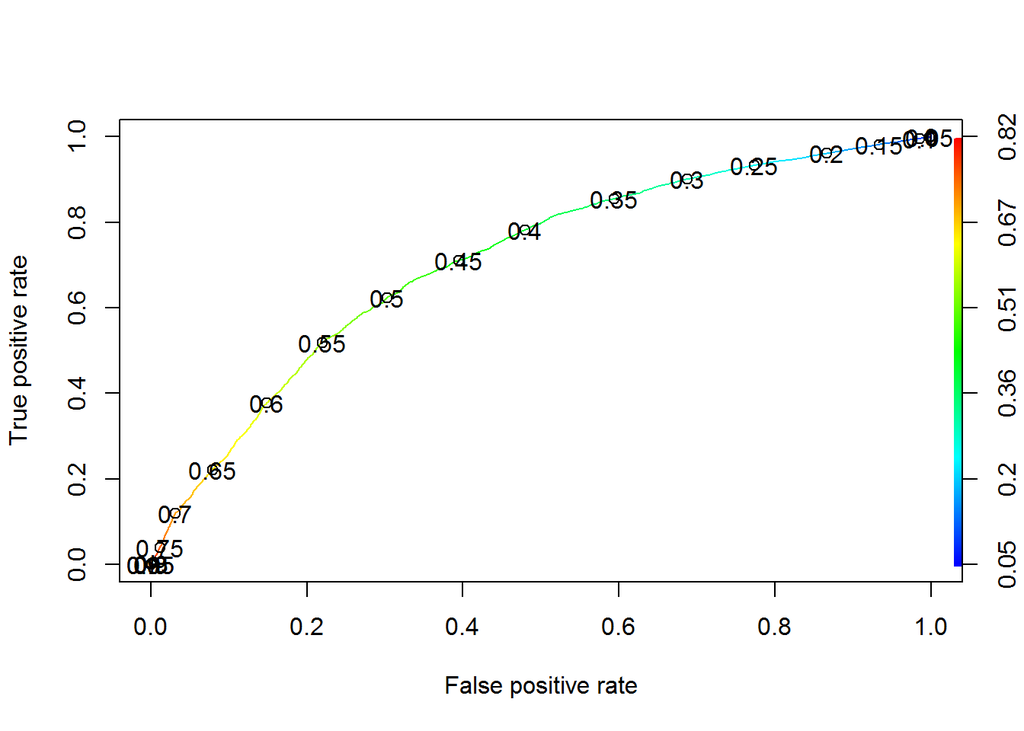

```r
pred <- prediction(prob_train, train_data$ExtraTime)

perf<- performance(pred, measure = "tpr", x.measure = "fpr") # Extracting performance measures (TPR and FPR)

plot(perf, col=rainbow(10), colorize = T, print.cutoffs.at = seq(0,1,0.05)) # PLotting ROC curve
```

```r
perf_auc <- performance(pred, measure = "auc")
perf_auc
```

```
## An object of class "performance"
## Slot "x.name":
## [1] "None"
##
## Slot "y.name":
## [1] "Area under the ROC curve"
##
## Slot "alpha.name":
## [1] "none"
##
## Slot "x.values":
## list()
##
## Slot "y.values":
## [[1]]
## [1] 0.7088932
##
##
## Slot "alpha.values":
## list()
```

```r
auc <- perf_auc@y.values[[1]] # auc score from the performace object
auc
```

```
## [1] 0.7088932
```

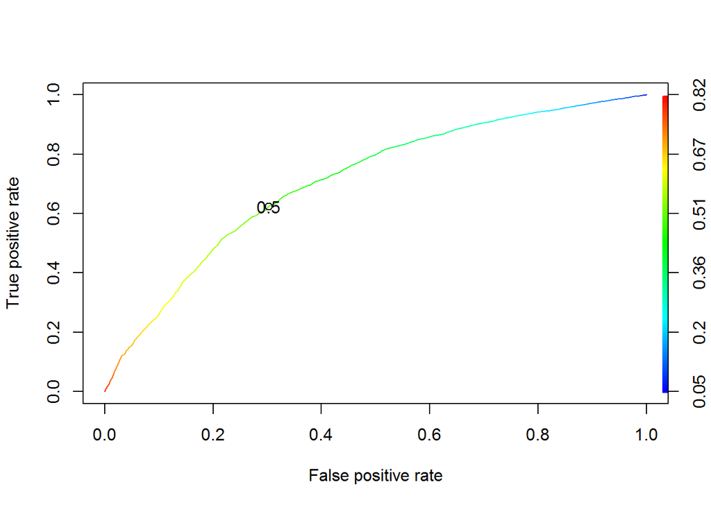

```r
plot(perf, col=rainbow(10), colorize = T, print.cutoffs.at = 0.5) # Cutoff chosen from ROC plot
```

# Prediction on validation data

```r
prob_test <- predict(log_reg, validation_data, type = "response")
preds_test <- ifelse(prob_test > 0.5, 'Yes' , 'No') # Cut off chosen is used here
```

```r
# Confusion Matrix

confusionMatrix(data = preds_test, reference = validation_data$ExtraTime, positive = "Yes")
```

```
## Confusion Matrix and Statistics
##
##           Reference
## Prediction   No  Yes
##        No  4526 2134
##        Yes 2029 3401
##
##                Accuracy : 0.6557
##                  95% CI : (0.6471, 0.6641)
##     No Information Rate : 0.5422
##     P-Value [Acc > NIR] : <2e-16
##
##                   Kappa : 0.3054
##  Mcnemar's Test P-Value : 0.107
##
##             Sensitivity : 0.6145
##             Specificity : 0.6905
##          Pos Pred Value : 0.6263
##          Neg Pred Value : 0.6796
##              Prevalence : 0.4578
##          Detection Rate : 0.2813
##    Detection Prevalence : 0.4491
##       Balanced Accuracy : 0.6525
##
##        'Positive' Class : Yes
##
```